# Auxiliar 03 - Repaso teórico y algunos cálculos

### CC5513 - Procesamiento Geométrico y Análisis de Formas

## Calentamiento

Aunque ya hemos añadido cantidades vectoriales a mallas, y cantidades escalares a nubes de puntos, entre otros, no hemos probado añadir cantidades escalares directamente a las mallas. Aprovecharemos para hacerlo buscando una propiedad que algunas veces uno quisiera visualizar en las mallas: los grados de los vértices. Esto es, cuántas aristas se conectan a cada vértice.

Podríamos simplemente observar una malla y buscar zonas con muchos triángulos concentrados, pero es más fácil si lo visualizamos con una cantidad escalar, y es bastante sencillo de implementar.

### Implementación

Nos basaremos en el código del auxiliar anterior, donde teníamos una función para calcular ángulos entre vectores, y funciones para obtener todas las normales de una malla (aunque sólo nos quedaremos con una de ellas, la más simple, aquella que simplemente sumaba las normales de las caras).

Ahora, para calcular el grado de los vértices, deberemos recorrerlos y contar cuántas caras están asociadas con cada vértice. En una malla sin bordes, la cántidad de caras por vértice es la misma que la cantidad de aristas por vértice.

```
def compute_vertex_degree(mesh: openmesh.TriMesh):
    """
    Stores the degree of every vertex and returns that scalar quantity.
    """
    degree = np.zeros(mesh.n_vertices())
    for vertex in mesh.vertices():
        face_it = openmesh.VertexFaceIter(mesh, vertex)
        for face in face_it:
            degree[vertex.idx()] += 1

    return degree
```

Con esta sencilla función, usando polyscope podemos visualizar esta cantidad escalar para distintas mallas.

```
parser = argparse.ArgumentParser()
parser.add_argument("--file", type=str, required=True,
                    help="Name of the file you want")
opt = parser.parse_args()
mesh = openmesh.read_trimesh(opt.file)

# degree
degree = compute_vertex_degree(mesh)

points = mesh.points()
normals = calculate_normals(mesh)

ps.init()
ps_mesh = ps.register_surface_mesh("mesh", points, mesh.face_vertex_indices())
ps_mesh.add_vector_quantity("normals (Avg of face normals)", normals)
ps_mesh.add_scalar_quantity("degree", degree)
ps.show()
```

## Procesamiento geométrico

¿Qué entendemos por procesamiento geométrico? Como dice su nombre, en realidad es aplicar algoritmos a nuestros modelos geométricos, que pueden ser de distintos tipos (suavizar superficies, simplificar las mallas, entre otros). Para poder hacerlo, de alguna manera tenemos que poder extraer información de la geometría, y cuando trabajamos con mallas una manera más intuitiva de hacerlo es la geometría diferencial.

La geometría diferencial nos permite estudiar la geometría de las manifolds, aunque en nuestro de las mallas (al menos del curso) tengamos un caso discreto. Y podemos hacerlo porque son 2-manifolds

### ¿Y qué entendemos por manifolds?

Antes de dar una definición, veamos algunos ejemplos discretos.

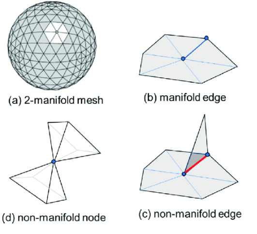

Aunque hay dos categorías (con borde y sin borde), un n-manifold podemos entenderlo como algo que 'al acercarse', se parece a $R^{n}$. Si por cada punto de una geometría podemos localmente ver algo parecido a $R^{n}$, entonces es un manifold.

Veamos por ejemplo una esfera. Una esfera (la superficie), es un 2-manifold, pues como es una superficie está definida en dos dimensiones (aunque la veamos en un espacio de 3 dimensiones desde fuera). Y es manifold, porque si tomamos un punto de ella y vemos su vecindad, se parece a $R^2$.

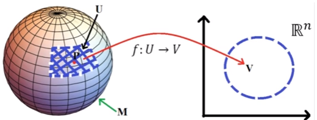

Si continuamos en espacios bidimensionales, lo bueno es que la búsqueda del parecido con $R^2$ lo podemos hacer buscando círculos. Utilizando esta idea, veamos cómo podemos aplicarla en el caso discreto de nuestras mallas geométricas.

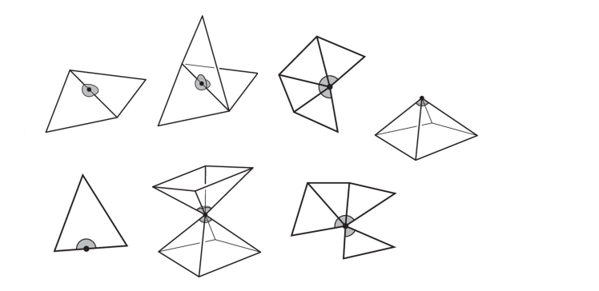

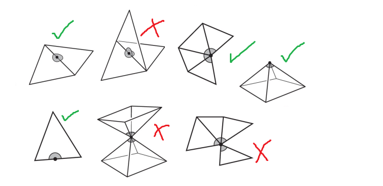

### Por qué tanta atención en los manifold?

Como veíamos antes, la geometría diferencial se estudia sobre manifolds, y es una herramienta que nos permite estudiar la geometría. Un ejemplo de esto es la tarea: podemos estudiarle la curvatura porque son manifolds, son cosas que localmente se parecen a nuestro $R^n$ de toda la vida.

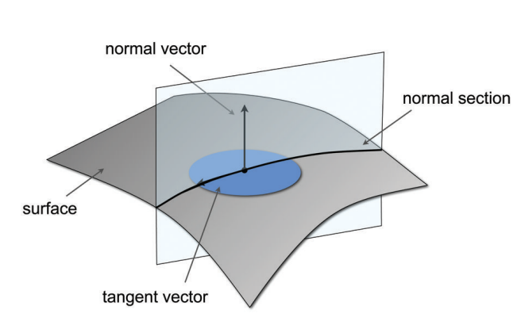

### Geometría intrínseca y extrínseca

Cuando estudiamos las distintas propiedades de los manifolds, veremos que hay algunas que se pueden calcular dentro del mismo espacio, sin salir hacia afuera del manifold.

Los detalles son un tanto matemáticos, pero podemos imaginarnoslo con una esfera y las geodésicas. Las geodésicas son el camino más corto entre dos puntos de la superficie, y como se definen sobre la superficie, no entran dentro de la esfera.

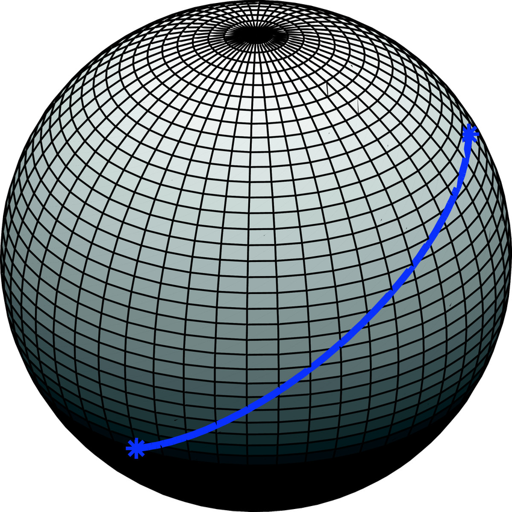

Las geometría intrínseca tiene que ver con aquellas cantidades que podemos calcular sin dejar nuestra manifold (mientras tengamos una noción de métrica, claro, sin depender de afuera).

Por el contrario, la geometría extrínseca considera a la superficie no como un espacio por sí mismo, sino como un objeto que vive en $R^n$. La curvatura media de un punto, que es la que calcularán en la tarea, es una de estas propiedades.

[Chapter 2, Intrinsic and extrinsic operators for shape analysis](https://par.nsf.gov/servlets/purl/10124353#:~:text=Intrinsic%20operators%20like%20the%20Laplacian,metric%20g%20remains%20the%20same.)

## Adelanto del próximo auxiliar

En el siguiente auxiliar, veremos una de las aplicaciones de poder obtener información de la geometría. Mientras tanto, utilizaremos lo que hicimos en el auxiliar anterior para aplicarle ruido a nuestras mallas, algo que será útil en el futuro.

Hacerlo en realidad es bastante directo. Podemos calcular las normales de cada vértice, y luego utilizarlas para desplazarlos ligeramente.

```
...

# noising
points = mesh.points()
normals = calculate_normals(mesh)
rho = np.random.normal(size=mesh.n_vertices())*0.02
points = points + np.multiply(np.ones(points.shape), rho[:,np.newaxis])*normals


ps.init()
...
```